# Day 11 Notes: Expected Value

## Today’s Agenda

- Random Variables
- Expected Value
- Uniform Distribution

## Random Variable

- A **random variable** is a numerical outcome to a random process.
- eg. A student has an assigned text book for a course. How much a random student in the course spends on the text book is a random variable, $X$.
- random variables are usually denoted with capitals $X$,$Y$,$Z$
- The book store assumes that students will either: not buy a book, buy the book used, or buy it brand new. The possible outcomes are usually denoted with lower case letters.
- Revenue for the book store is $x_1 = 0$, $x_2 = 137$, $x_3 = 170$ for the three possbilities and the book store believes they each occur with probability $.20$, $.55$, and $.25$ respectively. In probability notation:

$$P(X=0) = .20, \ P(X=137) = .55, \
P(X=170) = .25$$

Since there are only three possible outcomes, this is called a **discrete probability distribution**

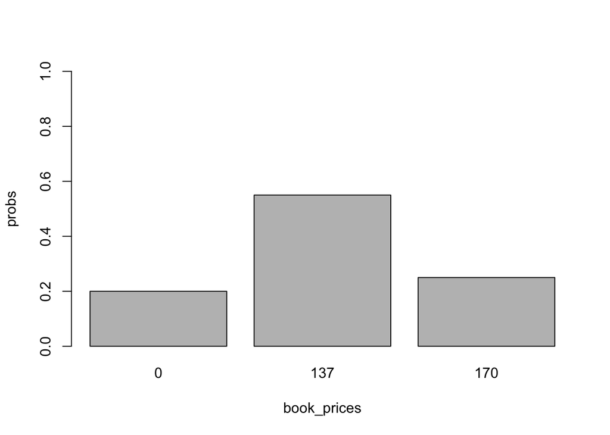

```r
probs <- c(.2,.55,.25)
book_prices <- c(0,137,170)
barplot(probs~book_prices,ylim=c(0,1))
```

Another discrete probability distribution is that of rolling a die:

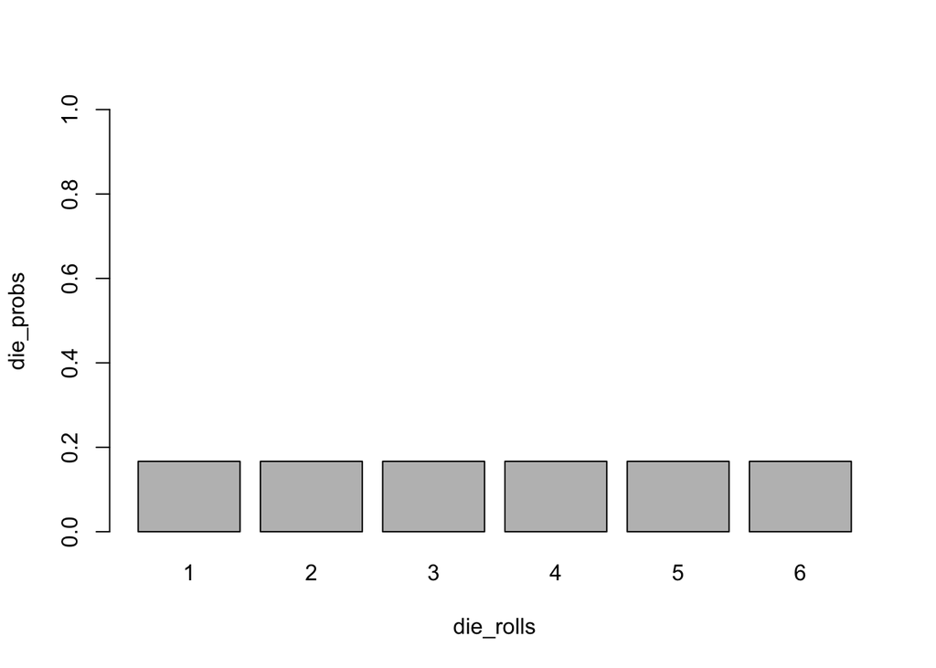

```r
die_probs <- c(1/6,1/6,1/6,1/6,1/6,1/6)
die_rolls <- c(1,2,3,4,5,6)
barplot(die_probs~die_rolls, ylim=c(0,1))
```

- all probabilites in a probability distribution must be between 0 and 1.
- the sum of all the probabilites must equal 1.
- discrete probability distributions only have finitely many possible outcomes.

## Expected Value

The expected value of a random variable is:

$$E(X) = x_1 \times P(X=x_1) + \dots + x_k
\times P(X=x_k) = \sum_{i=1}^k x_i P(X = x_i)$$

and the standard deviation of the expected value of the random variable is

$$\sqrt{\sum (x_i-E(X))^2 P(X =
x_i)}$$

If all the probabilities are the same, then
$$E(X) = x_1 \times \frac{1}{k} + \dots + x_k
\times \frac{1}{k} = \frac{\sum_{i=1}^k x_i}{k} = \bar{x}$$

this is just the mean.

eg. The expected price of a text book is

```r
# This finds each book price times each probability
probs*book_prices
```

```
## [1]  0.00 75.35 42.50
```

```r
# the expected value is the sum
sum(probs*book_prices)
```

```
## [1] 117.85
```

```r
# the expected cost of the book is $117.85
```

```r
# find the standard deviation of the price
sqrt(sum((117.85-book_prices)^2*probs))
```

```
## [1] 60.49238
```

## Unifrom Distribution

- When all probabilities are equally likely the distribution is called the **uniform distribution**.
- The expected value of a random variable with a uniform probability distribution is the mean of the possibilities